**SYS 6018 | Fall 2020 | University of Virginia** # keyu chen # km5ar *******************************************

### Problem 7.1: Tree Splitting for classification

Consider the Gini index, classification error, and entropy impurity measures in a simple classification setting with two classes.

Create a single plot that displays each of these quantities as a function of $p_m$, the estimated probability of an observation in node $m$ being from class 1. The x-axis should display $p_m$, ranging from 0 to 1, and the y-axis should display the value of the Gini index, classification error, and entropy.

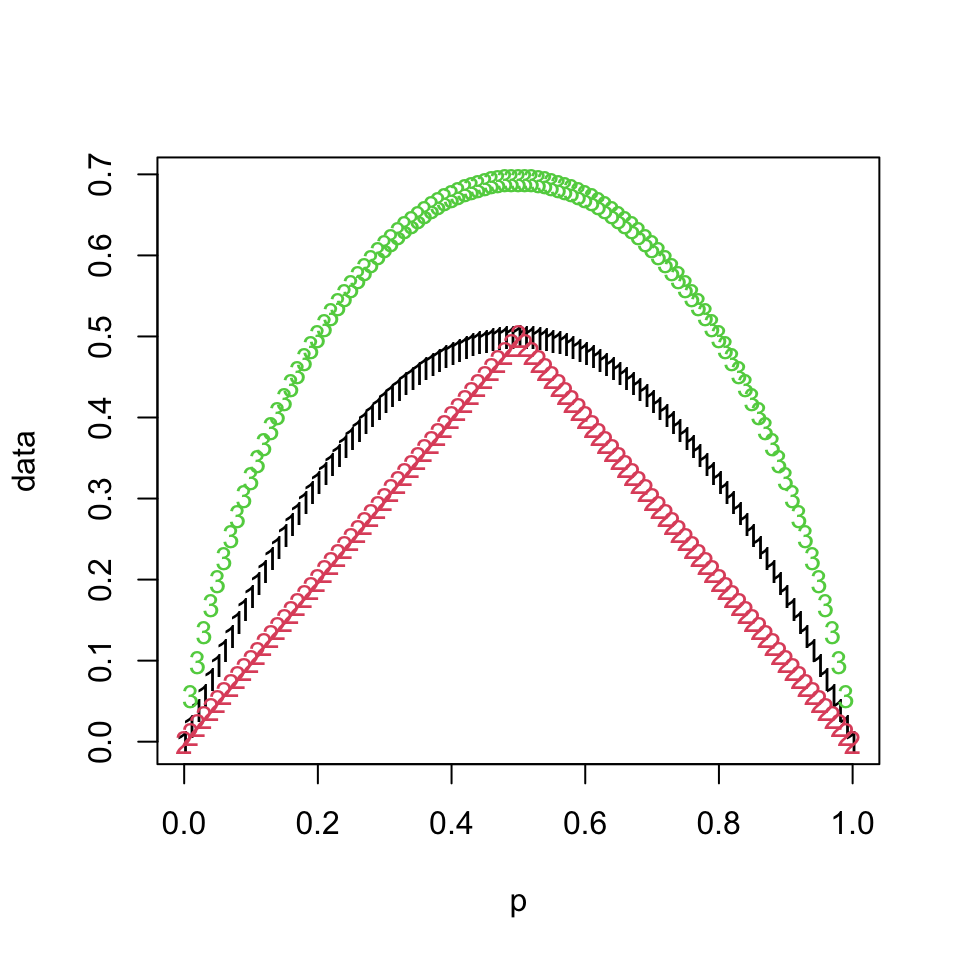

```r
p = seq(0, 1, 0.01)
gini_index = 2*(1 - p) *p
entropy = -(p * log(p) + (1 - p) * log(1 - p))
classification_error = 1 - pmax(p, 1 - p)
data = cbind(gini_index, classification_error, entropy)
matplot(p,data) # number 1: gini index, number 2: classcification error, 3: entropy
```

### Problem 7.2: Combining bootstrap estimates

Suppose we produce ten bootstrapped samples from a data set containing red and green classes. We then apply a classification tree to each bootstrapped sample and, for a specific value of $X$, produce the following 10 estimates of $\Pr(\text{Class is Red} \mid X)$: 0.2, 0.25, 0.3, 0.4, 0.4, 0.45, 0.7, 0.85, 0.9, 0.9

1. ISLR 8.2 describes the *majority vote* approach for making a hard classification from a set of bagged classifiers. What is the final classification for this example using majority voting?

the final classification for this exmaple using majority voting is : green, because there is total of 6 estimates are < than 0.5, while only 4 estimates are larger than 0.5.

2. An alternative is to base the final classification on the average probability. What is the final classification for this example using average probability?

the final classification for this example is Red. the average probability approch in this class will take all estimates’ average, in this case

$$(0.2 + 0.25 + 0.3 + 0.4 + 0.4 + 0.45 + 0.7 + 0.85 + 0.9 + 0.9)/10 = 0.535$$

3. Suppose the cost of mis-classifying a Red class is twice as costly as mis-classifying a Green class. How would you modify both approaches to make better final classifications under these unequal costs? Report the final classifications.

```r
p_red = c(0.2, 0.25, 0.3, 0.4, 0.4, 0.45, 0.7, 0.85, 0.9, 0.9)
p_green = 1 - p_red

cost_green = 2/3
cost_red = 1/3

red_after_cost = p_green*cost_green
green_after_cost = p_red*cost_red

red_df = c()
for (i in 1:length(p_red)) {
  red_df[i] = ifelse(red_after_cost[i]<green_after_cost[i], 1, 0)}
red = sum(red_df)
green = 10 - red

ifelse(red > green, 'red', 'green')
```

```
#> [1] "green"
```

so for majority vote approach, after the adjustment, the final classification for this example is: green

```r
avg_p_red = 0.535
avg_p_green = 1- avg_p_red

red_after_cost = avg_p_red*1/3
green_after_cost = avg_p_green*3/2
ifelse(red_after_cost > green_after_cost, 'red', 'green')
```

```
#> [1] "green"
```

after the cost adjustment, for average proability apporach, the final classification for this example is: green

### Problem 7.3: Random Forest Tuning

Random forest has several tuning parameters that you will explore in this problem. We will use the `Boston` housing data from the `MASS` R package (See the ISLR Lab in section 8.3.3 for example code).

- Note: remember that `MASS` can mask the `dplyr::select()` function.
1. List all of the random forest tuning parameters in the `randomForest::randomForest()` function. Note any tuning parameters that are specific to classification or regression problems. Which tuning parameters do you think will be most important to search?

```r
data(Boston, package="MASS")
```

```r
# https://www.rdocumentation.org/packages/randomForest/versions/4.6-14/topics/randomForest
```

# all of the random forest tuning parameters in the `randomForest::randomForest()` function.

1. mtry
2. min.obs
3. ntree
4. sampsize
5. cutoff
6. strata
7. nodesize
8. maxnodes
9. importance
10. nPerm
11. oob.prox
12. do.trace
13. corr.bias

# There are two primary tuning parameters for Random Forest( reference: Professor Porter):

1. m controls the number of predictors that are evaluated for each split (mtry argument in randomForest package)
2. The depth/size of the trees are controlled by setting the minimum number of observations in the leaf nodes (min.obs) or the depth of the tree
2. Use a random forest model to predict `medv`. Use the default parameters and report the 10-fold cross-validation MSE.

```r
set.seed(1234567890)
model =  train(medv~.,data = Boston, method = "ranger",
                trControl = trainControl("cv", number = 10),
                tuneLength = 10)
model
```

```
#> Random Forest
#>
#> 506 samples
#>  13 predictor
#>
#> No pre-processing
#> Resampling: Cross-Validated (10 fold)
#> Summary of sample sizes: 455, 455, 455, 455, 455, 456, ...
#> Resampling results across tuning parameters:
#>
#>   mtry  splitrule   RMSE      Rsquared   MAE
#>    2    variance    3.449627  0.8628191  2.359278
#>    2    extratrees  3.934814  0.8312545  2.648350
#>    3    variance    3.243495  0.8747574  2.246739
#>    3    extratrees  3.461253  0.8640043  2.361625
#>    4    variance    3.076332  0.8857675  2.159089
#>    4    extratrees  3.243076  0.8764281  2.225216
#>    5    variance    3.088874  0.8822934  2.163550
#>    5    extratrees  3.150433  0.8802681  2.185800
#>    6    variance    3.079004  0.8821913  2.160566
#>    6    extratrees  3.109555  0.8804529  2.166041
#>    8    variance    3.031436  0.8850515  2.145281
#>    8    extratrees  3.033374  0.8840693  2.127844
#>    9    variance    3.084743  0.8794270  2.174390
#>    9    extratrees  3.019507  0.8843411  2.132098
#>   10    variance    3.096288  0.8786693  2.191000
#>   10    extratrees  3.037561  0.8821132  2.134040
#>   11    variance    3.093986  0.8780280  2.199956
#>   11    extratrees  3.043229  0.8814760  2.142954
#>   13    variance    3.136987  0.8731271  2.224618
#>   13    extratrees  3.038304  0.8812887  2.141030
#>
#> Tuning parameter 'min.node.size' was held constant at a value of 5
#> RMSE was used to select the optimal model using the smallest value.
#> The final values used for the model were mtry = 9, splitrule = extratrees
#>  and min.node.size = 5.
```

```r
model$bestTune
```

```
#>    mtry  splitrule min.node.size
#> 14    9 extratrees             5
```

```r
set.seed(111)
train = sample(1:nrow(Boston), nrow(Boston)/2)

rf.boston =randomForest(medv~.,data=Boston, subset = train, mtry=9, importance =TRUE)
yhat.rf = predict(rf.boston ,newdata =Boston[-train,])
yhat.rf
```

[output not shown]

[output cut: 9 more lines]

[output not shown]

3. Now we will vary the tuning parameters of `mtry` and `ntree` to see what effect they have on performance.
   - Use a range of reasonable `mtry` and `ntree` values.
   - Use 5 times repeated out-of-bag (OOB) to assess performance. That is, run random forest 5 times for each tuning set, calculate the OOB MSE each time and use the average for the MSE associated with the tuning parameters.
   - Use a plot to show the average MSE as a function of `mtry` and `ntree`.
   - Report the best tuning parameter combination.
   - Note: random forest is a stochastic model; it will be different every time it runs. Set the random seed to control the uncertainty associated with the stochasticity.
   - Hint: If you use the `randomForest` package, the `mse` element in the output is a vector of OOB MSE values for 1:`ntree` trees in the forest. This means that you can set `ntree` to some maximum value and get the MSE for any number of trees less than `ntree`.

```r
set.seed(123)

mtry_list = c(5, 6,7,8,9,10,11,12)  # create a range of mtry
ntree_list = c(20, 30, 40,50,60,70,80,90) # create a range of ntree
OOB_mse_matrix = matrix(NA, 8, 8) # OBB matrix

for (i in 1:8) {  # for loop
  for(w in 1:8) {
    MSE_pip = numeric(5)
    for (s in 1:5){  # for loop 5 times
      model = randomForest(medv~., data=Boston, mtry=mtry_list[i], ntree=90)  # model with ntree =90
      mse_ntree = ntree_list[w]
      MSE_pip[s] = model$mse[mse_ntree]}
    OOB_mse_matrix[w, i] = mean(MSE_pip)}}

library(RColorBrewer)
coul <- colorRampPalette(brewer.pal(8, "PiYG"))(25)
final <-  cbind(ntree_list, OOB_mse_matrix)
final
```

```
#>      ntree_list
#> [1,]         20 11.676860 11.97613 11.52490 11.977784 11.91985 12.96630
#> [2,]         30 11.262050 11.39611 11.86973 10.859674 10.90744 10.41327
#> [3,]         40 10.733505 10.79987 10.80823 10.942004 10.94038 10.52983
#> [4,]         50 10.289335 10.89246 10.13231 10.410824 10.11567 10.70765
#> [5,]         60 10.571602 10.05538 10.17081 10.358108 10.09714 10.49175
#> [6,]         70  9.708736 10.09489 10.49593 10.345018 10.73522 10.42998
#> [7,]         80 10.169335 10.33479 10.20759 10.199756 10.17019 10.32631
#> [8,]         90 10.497170 10.39483 10.05056  9.819747 10.13279 10.27926
#>
#> [1,] 11.86165 12.69585
#> [2,] 11.05662 11.68324
#> [3,] 10.90507 10.98639
#> [4,] 10.95525 11.04531
#> [5,] 10.99670 10.72572
#> [6,] 10.34546 10.97035
#> [7,] 10.30918 10.62918
#> [8,] 10.77734 10.61222
```

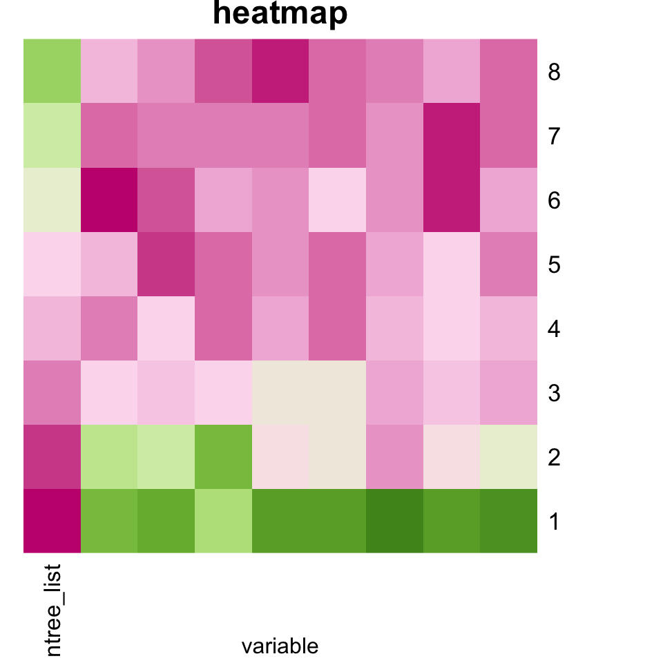

```r
heatmap(final, Colv = NA, Rowv = NA, scale="column", col = coul, xlab="variable", main="heatmap") # reference https://www.r-graph-gallery.com/heatmap
```

reference: joined a group of people in slack for discussion (hosted by kip, on OCT 21, 7PM)